# BÁO CÁO CHI TIẾT TCM_YEAR_2025

Author

Hoang Quoc Cuong

Published

April 23, 2026

# **TCM 2025**

Báo cáo được cập nhập vào lúc **2026-04-23 16:52:51 | Dữ liệu TCM 2025**

Bản đồ Cần Thơ (thông tin chi tiết phường, xã mới) [**click here**](https://tuhocr.github.io/canthosxh/MAP_CANTHO)

**Để copy file ảnh đồ thị full-size, ta right-click lên hình, chọn `Open image in new tab`**

# 1 **KIỂM TRA DỮ LIỆU**

**Nhập dữ liệu sai lệch năm (vd: file 2025 nhưng lại có bệnh nhân của năm 2026)**

**`Dữ liệu nhập lệch năm`**

```
Dữ liệu ban đầu: 7050
Dữ liệu sau khi lọc theo năm: 7026
Dữ liệu nhập lệch năm: 24
                   TTYTKV PHUONG_XA_MOI    NGAY_VV                HO    TEN TUOI NGUOI_NHAP_LIEU NGAY_NHAP_LIEU
151       TTYT KV Kế Sách   An Lạc Thôn 2026-02-01          Võ Thành    Phú 2.00     CDC Cần Thơ     2026-01-13
812   TTYT KV Cù Lao Dung   Cù Lao Dung 2026-01-01            Đỗ Đức  Thịnh 4.00     CDC Cần Thơ     2026-01-13
1454     TTYT KV Mỹ Xuyên        Hòa Tú 2026-04-01          Đổ Khánh   Băng 3.00     CDC Cần Thơ     2026-01-13
1658      TTYT KV Kế Sách       Kế Sách 2026-01-01           Lâm Phú  Trọng 2.00     CDC Cần Thơ     2026-01-13
2307        TTYT KV Mỹ Tú      Mỹ Hương 2026-01-01         Vũ Cát An  Nhiên 2.00     CDC Cần Thơ     2026-01-13
2331        TTYT KV Mỹ Tú      Mỹ Hương 2026-01-01          Bùi Minh    Duy 2.00     CDC Cần Thơ     2026-01-13
2529 TTYT KV TP Sóc Trăng      Mỹ Xuyên 2026-01-02          Danh Yến  Hương 2.00     CDC Cần Thơ     2026-01-13
2567 TTYT KV TP Sóc Trăng      Mỹ Xuyên 2026-01-01            Võ Gia   Long 2.00     CDC Cần Thơ     2026-01-13
2568 TTYT KV TP Sóc Trăng      Mỹ Xuyên 2026-01-01 Nguyễn Huỳnh Đăng   Khoa 3.00     CDC Cần Thơ     2026-01-13
2624 TTYT KV TP Sóc Trăng      Mỹ Xuyên 2026-02-01          Danh Yến    Nhi 5.00     CDC Cần Thơ     2026-01-13
3111        TTYT KV Ô Môn         Ô Môn 2026-05-01   Trần Quỳnh Trúc Phương 2.00     CDC Cần Thơ     2026-01-13
3600 TTYT KV TP Sóc Trăng       Phú Lợi 2026-01-01           Lê Thảo   Uyên 2.00     CDC Cần Thơ     2026-01-13
3840        TTYT KV Ô Môn    Phước Thới 2026-02-01   Đinh Phạm Hoàng   Khôi 1.00     CDC Cần Thơ     2026-01-13
3938 TTYT KV TP Sóc Trăng     Sóc Trăng 2026-01-01         Cao Mã Tú   Uyên 2.00     CDC Cần Thơ     2026-01-13
3949 TTYT KV TP Sóc Trăng     Sóc Trăng 2026-01-01         Lâm Thanh  Hoàng 1.00     CDC Cần Thơ     2026-01-13
4418 TTYT KV Châu Thành A       Tân Hòa 2026-02-01   Nguyễn Ngọc Bảo   Trân 1.19     CDC Cần Thơ     2026-01-13
4534      TTYT KV Ngã Năm      Tân Long 2026-01-01  Nguyễn Hoàng Gia  Khiêm 2.00     CDC Cần Thơ     2026-01-13
4755   TTYT KV Phụng Hiệp     Thạnh Hòa 2026-02-01         Đặng Minh   Đăng 1.58     CDC Cần Thơ     2026-01-13
4907      TTYT KV Trần Đề Thạnh Thới An 2026-01-01      Trần Thị Như  Quyền 5.00     CDC Cần Thơ     2026-01-13
6204     TTYT KV Long Phú  Trường Khánh 2026-01-01          Trần Phú   Đăng 1.00     CDC Cần Thơ     2026-01-13
6602      TTYT KV Vị Thủy       Vị Thủy 2026-01-01       Nguyễn Ngọc   Thảo 2.00     CDC Cần Thơ     2026-01-13
6661    TTYT KV Thạnh Trị      Vĩnh Lợi 2026-02-01           Đàm Hữu  Trọng 8.00     CDC Cần Thơ     2026-01-13
6976      TTYT KV Vị Thủy    Vĩnh Tường 2026-01-01       Huỳnh Tuyết   Ngân 1.60     CDC Cần Thơ     2026-01-13
6990      TTYT KV Long Mỹ     Vĩnh Viễn 2026-01-01     Lê Hoàng Trúc     Vy 2.00     CDC Cần Thơ     2026-01-13
```

**Nếu tổng số `TTYTKV` không vượt quá 22 (năm 2025) hay 20 (năm 2026) thì dữ liệu chính xác.**

**Tổng số TTYTKV là 22**

**`TTYTKV`**

```
    TTYT KV Bình Thủy      TTYT KV Cái Răng  TTYT KV Châu Thành A TTYT KV Châu Thành HG TTYT KV Châu Thành ST   TTYT KV Cù Lao Dung
                  720                   453                   116                   159                   233                   230
      TTYT KV Kế Sách       TTYT KV Long Mỹ      TTYT KV Long Phú         TTYT KV Mỹ Tú      TTYT KV Mỹ Xuyên       TTYT KV Ngã Năm
                  367                   191                   323                   303                   182                   132
        TTYT KV Ô Môn    TTYT KV Phụng Hiệp     TTYT KV Thạnh Trị      TTYT KV Thới Lai      TTYT KV Thốt Nốt  TTYT KV TP Sóc Trăng
                  317                   534                    91                   447                   547                   470
      TTYT KV Trần Đề       TTYT KV Vị Thủy     TTYT KV Vĩnh Châu    TTYT KV Vĩnh Thạnh
                  405                   388                   129                   289
Tổng số TTYTKV là 22
```

**Nếu tổng số `PHUONG_XA_MOI` không vượt quá 103 thì dữ liệu chính xác.**

**Tổng số PHUONG_XA_MOI là 103**

**`PHUONG_XA_MOI`**

```
        An Bình     An Lạc Thôn         An Ninh        An Thạnh       Bình Thủy         Cái Khế        Cái Răng      Châu Thành
            101              70              62             100              82              96             161              56
          Cờ Đỏ     Cù Lao Dung         Đại Hải        Đại Ngãi       Đại Thành       Đông Hiệp      Đông Phước      Đông Thuận
             36             130              63              49              52              22              37              38
        Gia Hòa       Hiệp Hưng     Hồ Đắc Kiện          Hòa An         Hỏa Lựu          Hòa Tú        Hưng Phú         Kế Sách
             37              88              53              50              59              32             117              90
      Khánh Hòa         Lai Hòa         Lâm Tân Lịch Hội Thượng         Liêu Tú       Long Bình       Long Hưng         Long Mỹ
             32              17              28              44              46              30              49              28
       Long Phú      Long Phú 1      Long Tuyền       Lương Tâm        Mỹ Hương        Mỹ Phước         Mỹ Quới           Mỹ Tú
            109              22              88              42             140              24              45              90
       Mỹ Xuyên         Ngã Bảy         Ngã Năm         Ngọc Tố         Nhơn Ái         Nhơn Mỹ         Nhu Gia       Ninh Kiều
            109              48              44              70              47              82              43             142
          Ô Môn      Phong Điền       Phong Nẫm         Phú Hữu         Phú Lộc         Phú Lợi         Phú Tâm      Phụng Hiệp
            133              93               8              66              42             207              60              87
     Phước Thới     Phương Bình       Sóc Trăng         Tài Văn          Tân An        Tân Bình         Tân Hòa         Tân Lộc
             79              41             154              93             175              48              38              76
       Tân Long  Tân Phước Hưng       Tân Thạnh        Thạnh An       Thạnh Hòa       Thạnh Phú      Thạnh Quới   Thạnh Thới An
             43              39             100              23              81              17              85              81
     Thạnh Xuân    Thới An Đông     Thới An Hội       Thới Hưng        Thới Lai       Thới Long        Thốt Nốt       Thuận Hòa
             47              36              54              35              95             105             196              58
     Thuận Hưng         Trần Đề      Trung Hưng      Trung Nhứt    Trường Khánh     Trường Long Trường Long Tây    Trường Thành
            158             141             117             117              65              35              31              50
    Trường Xuân          Vị Tân        Vị Thanh      Vị Thanh 1         Vị Thủy       Vĩnh Châu        Vĩnh Hải        Vĩnh Lợi
             37              69              66              60              45              40              12              21
     Vĩnh Phước      Vĩnh Thạnh Vĩnh Thuận Đông      Vĩnh Trinh      Vĩnh Tường       Vĩnh Viễn        Xà Phiên
             28             120              42              61              47              29              40
Tổng số PHUONG_XA_MOI là 103
```

**Nếu kết quả tổng số ca theo `TTYTKV` và `PHUONG_XA_MOI` không vượt quá 103 thì dữ liệu chính xác.**

Số liệu này thể hiện bao nhiều phường xã có ca bệnh tương ứng với trung tâm y tế khu vực, tổng số không vượt qua 103 phường xã. Cần kiểm tra xem 1 phường xã có bị trùng ở các trung tâm y tế khu vực khác nhau không.

**Dữ liệu bị trùng**

```
        An Bình     An Lạc Thôn         An Ninh        An Thạnh       Bình Thủy         Cái Khế        Cái Răng      Châu Thành
              1               1               1               1               1               1               1               1
          Cờ Đỏ     Cù Lao Dung         Đại Hải        Đại Ngãi       Đại Thành       Đông Hiệp      Đông Phước      Đông Thuận
              1               1               1               1               1               1               1               1
        Gia Hòa       Hiệp Hưng     Hồ Đắc Kiện          Hòa An         Hỏa Lựu          Hòa Tú        Hưng Phú         Kế Sách
              1               1               1               1               1               1               1               1
      Khánh Hòa         Lai Hòa         Lâm Tân Lịch Hội Thượng         Liêu Tú       Long Bình       Long Hưng         Long Mỹ
              1               1               1               1               1               1               1               1
       Long Phú      Long Phú 1      Long Tuyền       Lương Tâm        Mỹ Hương        Mỹ Phước         Mỹ Quới           Mỹ Tú
              1               1               1               1               1               1               1               1
       Mỹ Xuyên         Ngã Bảy         Ngã Năm         Ngọc Tố         Nhơn Ái         Nhơn Mỹ         Nhu Gia       Ninh Kiều
              1               1               1               1               1               1               1               1
          Ô Môn      Phong Điền       Phong Nẫm         Phú Hữu         Phú Lộc         Phú Lợi         Phú Tâm      Phụng Hiệp
              1               1               1               1               1               1               1               1
     Phước Thới     Phương Bình       Sóc Trăng         Tài Văn          Tân An        Tân Bình         Tân Hòa         Tân Lộc
              1               1               1               1               1               1               1               1
       Tân Long  Tân Phước Hưng       Tân Thạnh        Thạnh An       Thạnh Hòa       Thạnh Phú      Thạnh Quới   Thạnh Thới An
              1               1               1               1               1               1               1               1
     Thạnh Xuân    Thới An Đông     Thới An Hội       Thới Hưng        Thới Lai       Thới Long        Thốt Nốt       Thuận Hòa
              1               1               1               1               1               1               1               1
     Thuận Hưng         Trần Đề      Trung Hưng      Trung Nhứt    Trường Khánh     Trường Long Trường Long Tây    Trường Thành
              1               1               1               1               1               1               1               1
    Trường Xuân          Vị Tân        Vị Thanh      Vị Thanh 1         Vị Thủy       Vĩnh Châu        Vĩnh Hải        Vĩnh Lợi
              1               1               1               1               1               1               1               1
     Vĩnh Phước      Vĩnh Thạnh Vĩnh Thuận Đông      Vĩnh Trinh      Vĩnh Tường       Vĩnh Viễn        Xà Phiên
              1               1               1               1               1               1               1
Tổng số PHUONG_XA_MOI là 103
[1] TTYTKV        PHUONG_XA_MOI TONG_SO_CA
<0 rows> (or 0-length row.names)
```

# 2 **SỐ** **CA** **THEO NGÀY [DỮ LIỆU GỐC]**

[**Dữ liệu gốc TCM_2025**](https://tuhocr.github.io/canthosxh/REPORT/TCM_2025)

# 3 **TỔNG SỐ** **CA** **TRONG NĂM THEO KHU VỰC**

**Từ ngày 2025-01-01 đến ngày 2025-12-31**

**Tổng số ca: 7026 | Tổng số TTYT KV: 22 | Tổng số phường, xã: 103**

**Tổng số phường, xã có ca TCM: 103**

| TTYTKV | Phường, xã mới | Tổng số ca |
| --- | --- | --- |
| TTYT KV Bình Thủy | Tân An | 175 |
| TTYT KV Bình Thủy | Ninh Kiều | 142 |
| TTYT KV Bình Thủy | An Bình | 101 |
| TTYT KV Bình Thủy | Cái Khế | 96 |
| TTYT KV Bình Thủy | Long Tuyền | 88 |
| TTYT KV Bình Thủy | Bình Thủy | 82 |
| TTYT KV Bình Thủy | Thới An Đông | 36 |
| TTYT KV Châu Thành A | Thạnh Xuân | 47 |
| TTYT KV Châu Thành A | Tân Hòa | 38 |
| TTYT KV Châu Thành A | Trường Long Tây | 31 |

[output cut: 93 more lines]

# 4 **ĐỒ THỊ TỔNG SỐ** **CA** **THEO KHU VỰC**

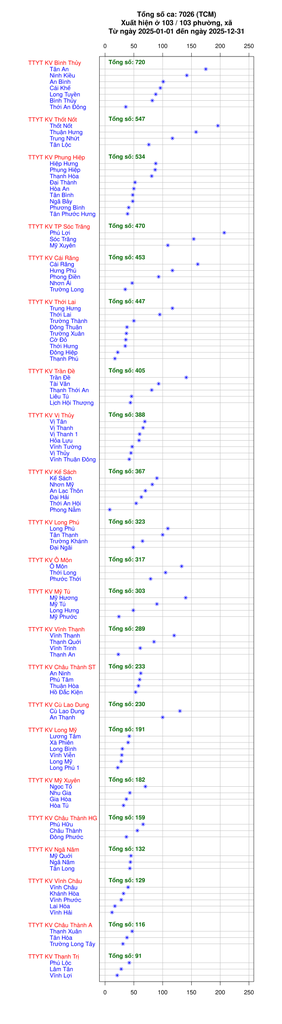

# 5 **TỔNG SỐ** **CA** **THEO THÁNG**

| TTYTKV | Phường, xã mới | Tháng | Tổng số ca |
| --- | --- | --- | --- |
| TTYT KV Bình Thủy | An Bình | 1 | 5 |
| TTYT KV Kế Sách | An Lạc Thôn | 1 | 1 |
| TTYT KV Châu Thành ST | An Ninh | 1 | 1 |
| TTYT KV Cù Lao Dung | An Thạnh | 1 | 2 |
| TTYT KV Bình Thủy | Bình Thủy | 1 | 4 |
| TTYT KV Bình Thủy | Cái Khế | 1 | 6 |
| TTYT KV Cái Răng | Cái Răng | 1 | 4 |
| TTYT KV Cù Lao Dung | Cù Lao Dung | 1 | 8 |
| TTYT KV Kế Sách | Đại Hải | 1 | 1 |
| TTYT KV Long Phú | Đại Ngãi | 1 | 4 |

[output cut: 1146 more lines]

# 6 **ĐỒ THỊ TỔNG SỐ** **CA** **THEO THỜI GIAN**

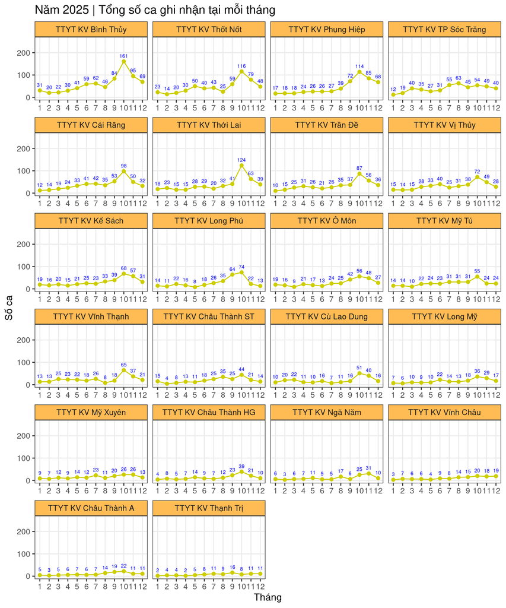

[figure not shown]

# 7 **TỔNG SỐ** **CA** **THEO TUẦN**

| TTYTKV | PHUONG_XA_MOI | WEEK | COUNT |
| --- | --- | --- | --- |
| TTYT KV Bình Thủy | An Bình | 1 | 1 |
| TTYT KV Kế Sách | An Lạc Thôn | 1 | 1 |
| TTYT KV Châu Thành ST | An Ninh | 1 | 1 |
| TTYT KV Bình Thủy | Bình Thủy | 1 | 2 |
| TTYT KV Bình Thủy | Cái Khế | 1 | 1 |
| TTYT KV Cù Lao Dung | Cù Lao Dung | 1 | 1 |
| TTYT KV Long Phú | Đại Ngãi | 1 | 1 |
| TTYT KV Châu Thành HG | Đông Phước | 1 | 1 |
| TTYT KV Long Mỹ | Long Bình | 1 | 1 |
| TTYT KV Bình Thủy | Long Tuyền | 1 | 1 |

[output cut: 3052 more lines]

# 8 **ĐỒ THỊ THEO NGÀY**

## 8.1 TTYT KV Long Phú

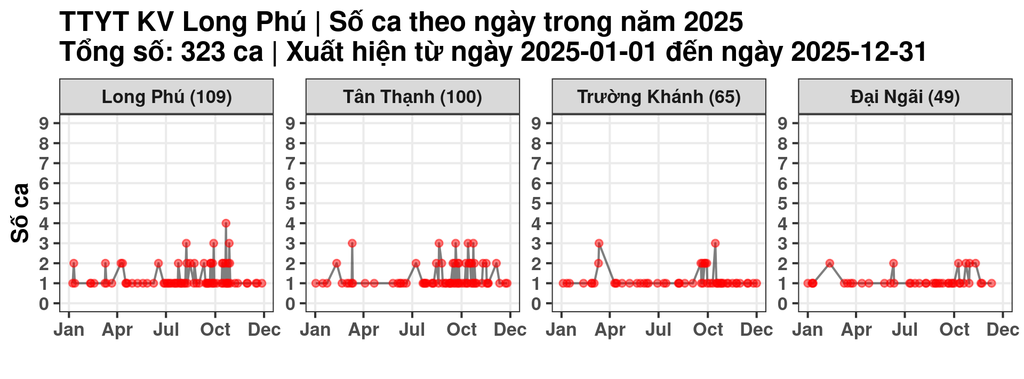

## 8.2 TTYT KV TP Sóc Trăng

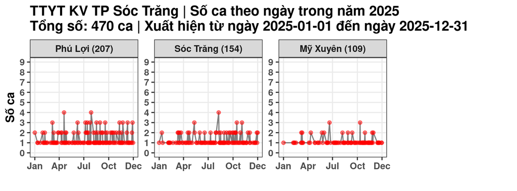

## 8.3 TTYT KV Mỹ Xuyên

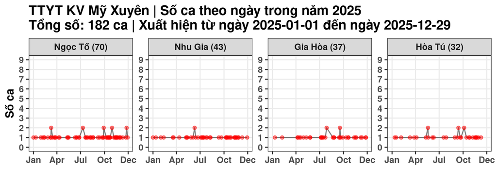

## 8.4 TTYT KV Bình Thủy

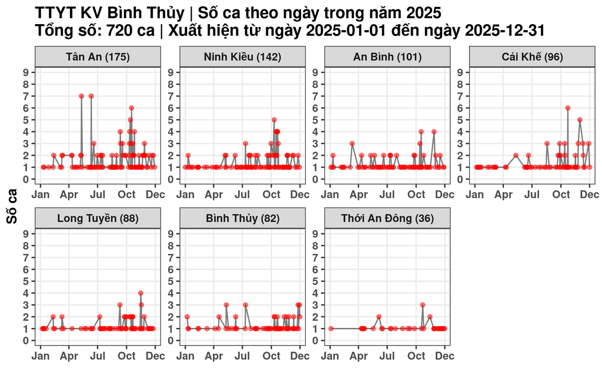

## 8.5 TTYT KV Ô Môn

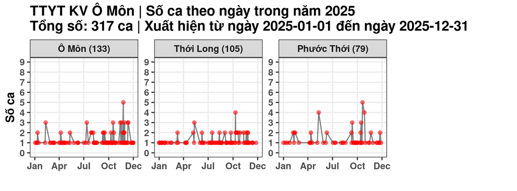

## 8.6 TTYT KV Thốt Nốt

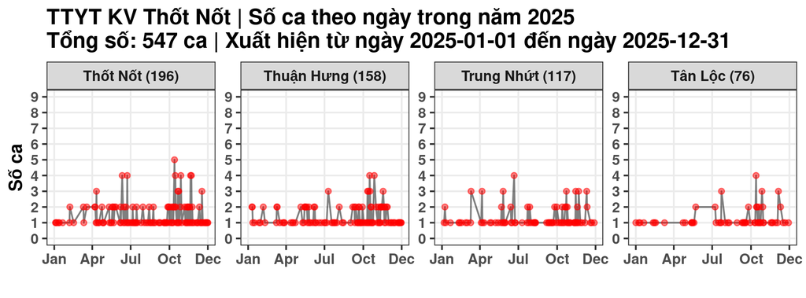

## 8.7 TTYT KV Ngã Năm

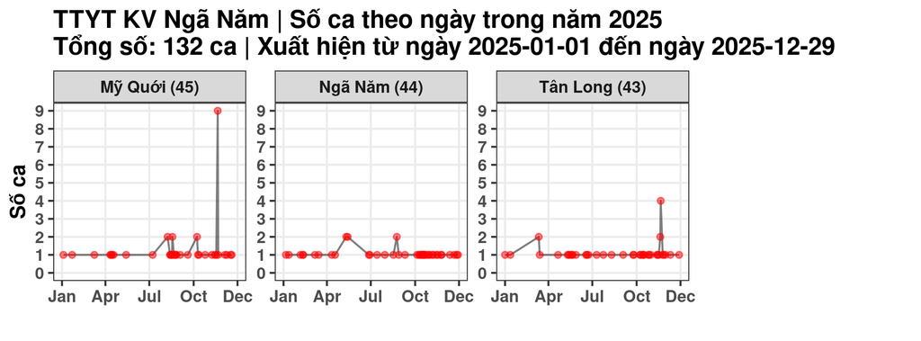

## 8.8 TTYT KV Vĩnh Thạnh

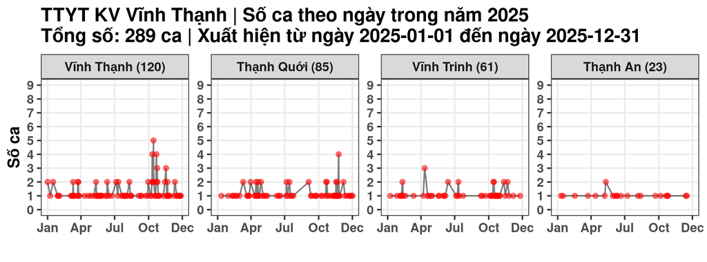

## 8.9 TTYT KV Châu Thành ST

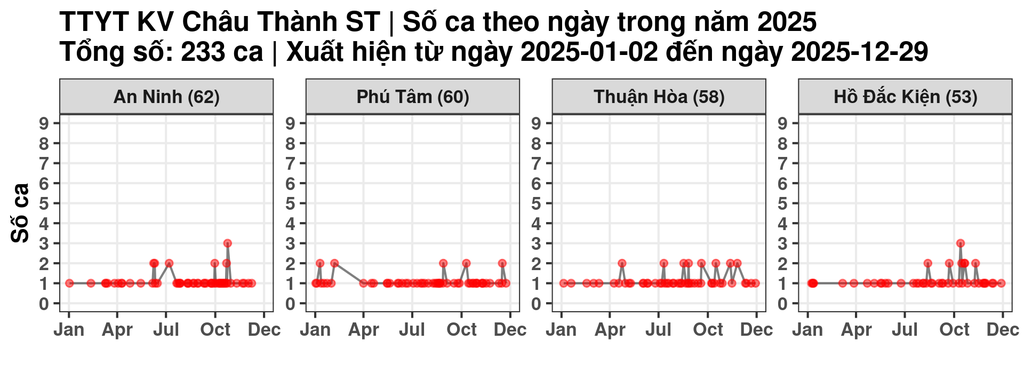

## 8.10 TTYT KV Kế Sách

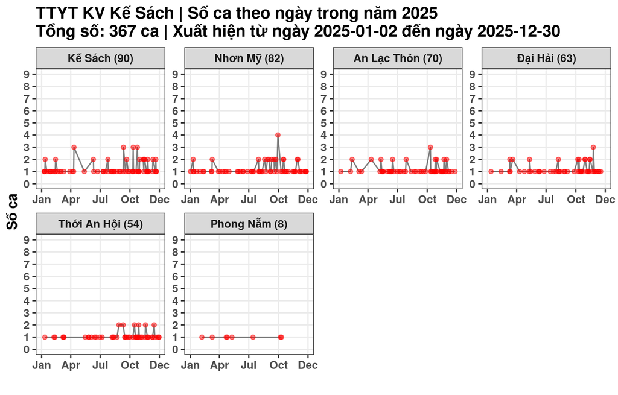

## 8.11 TTYT KV Trần Đề

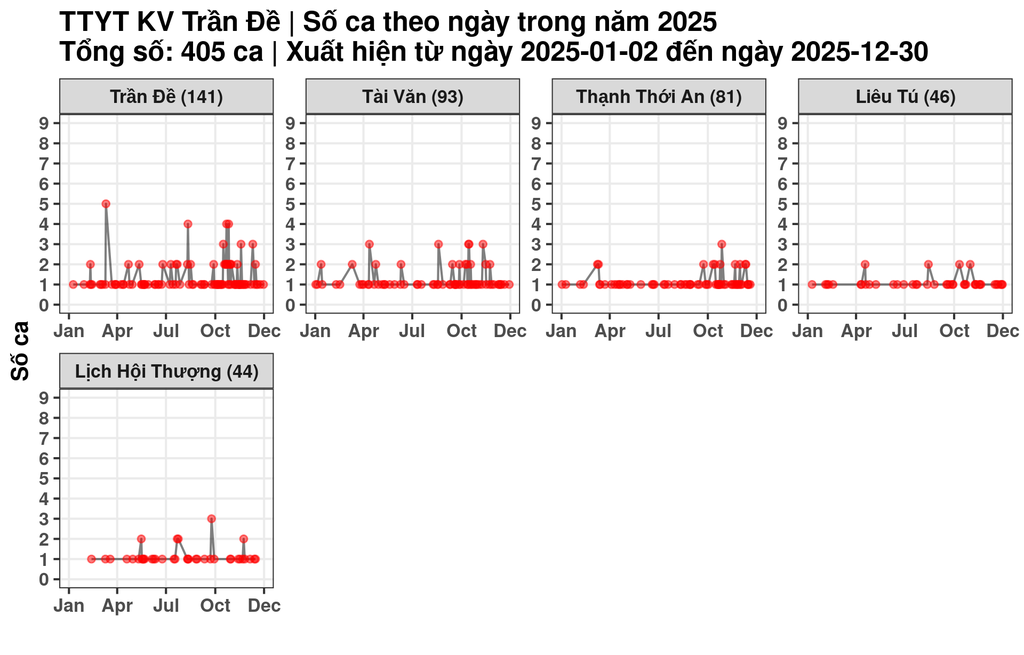

## 8.12 TTYT KV Cù Lao Dung

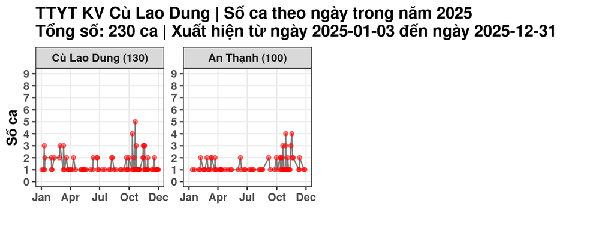

## 8.13 TTYT KV Mỹ Tú

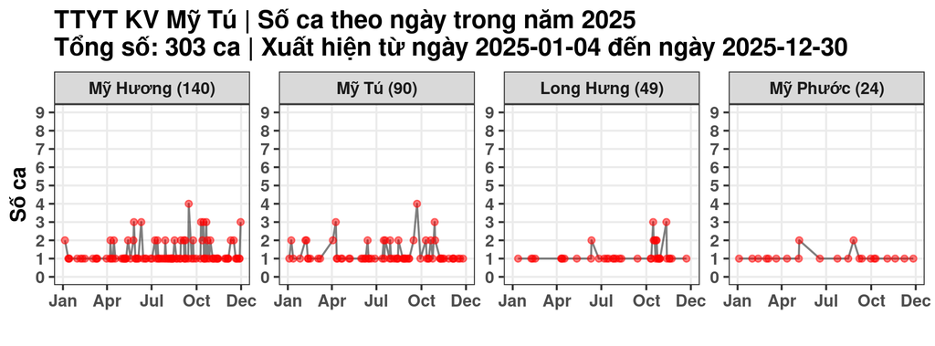

## 8.14 TTYT KV Thới Lai

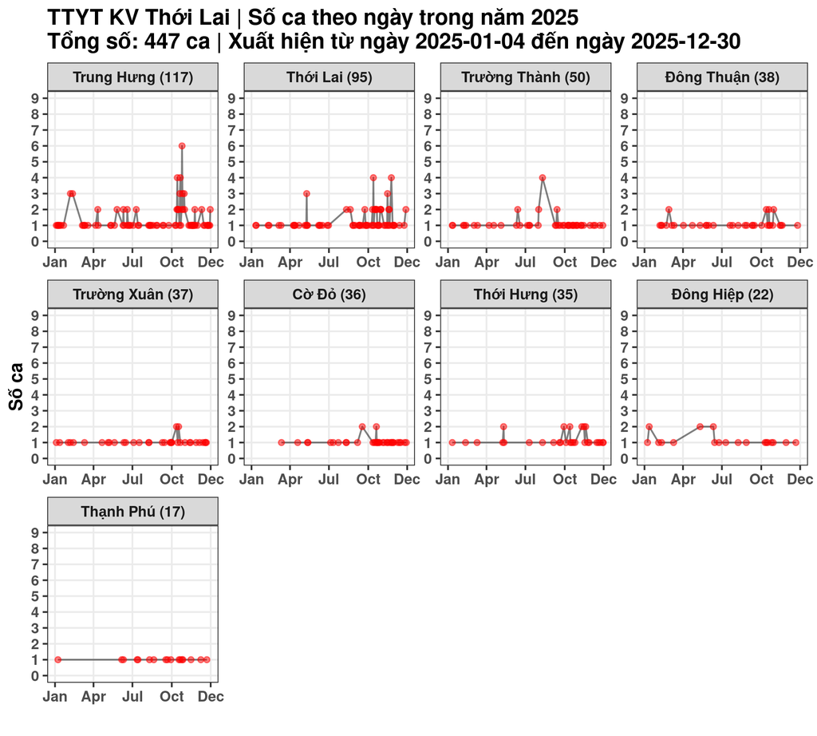

## 8.15 TTYT KV Phụng Hiệp

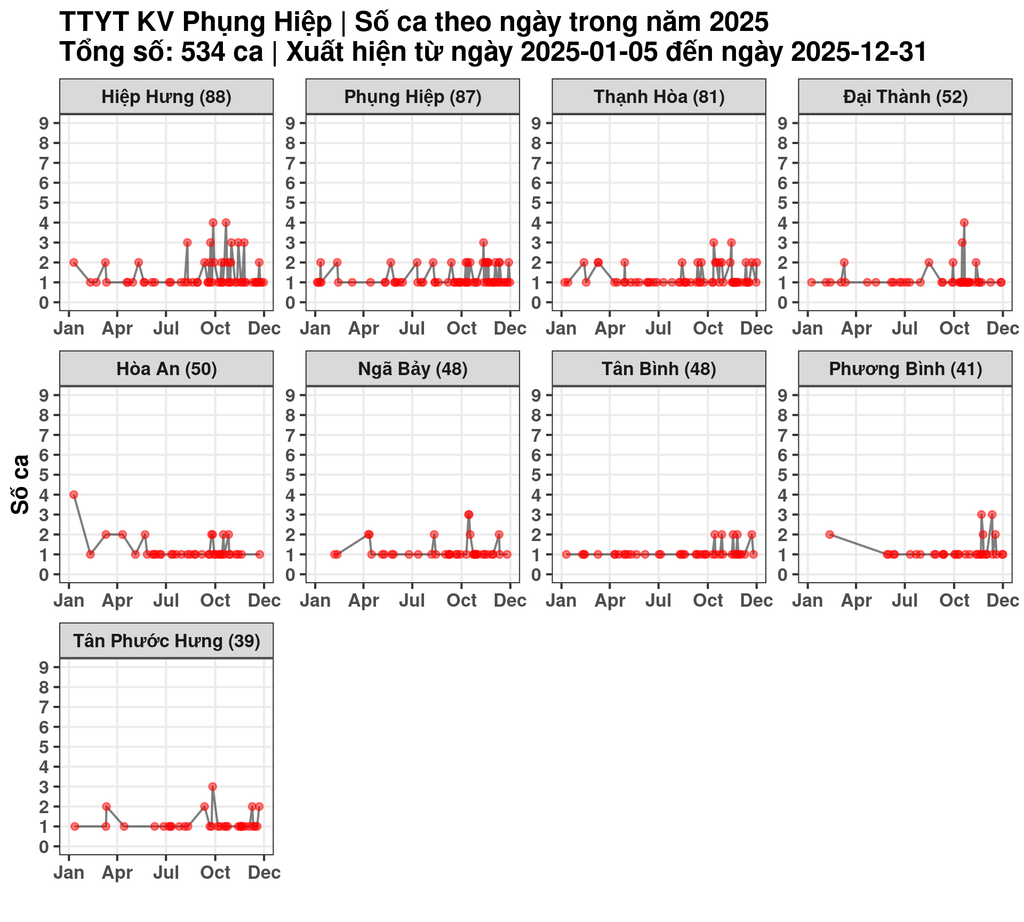

## 8.16 TTYT KV Long Mỹ

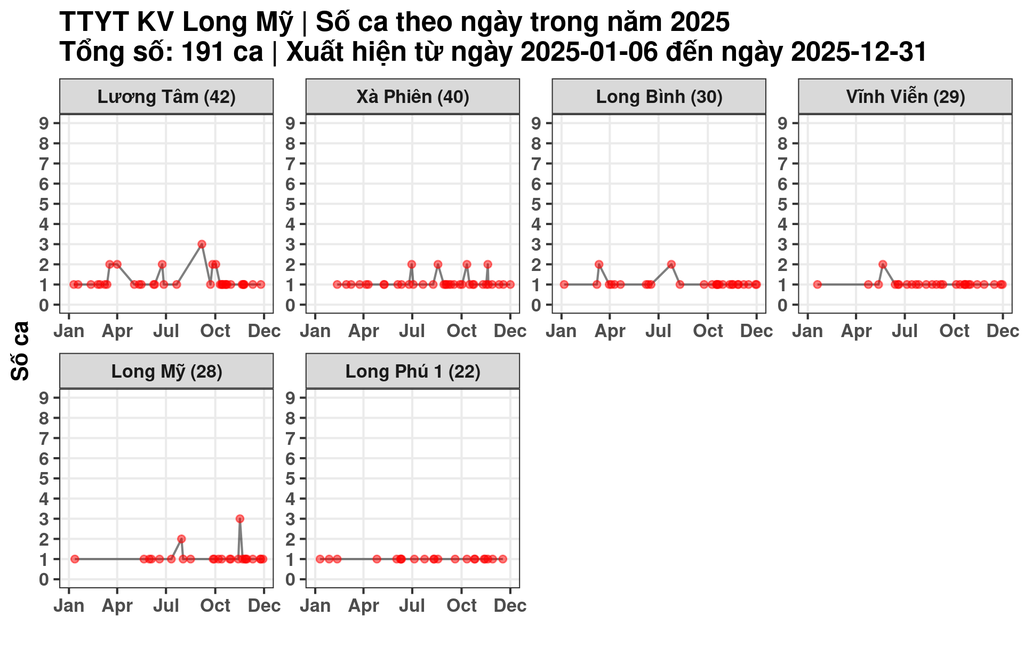

## 8.17 TTYT KV Vị Thủy

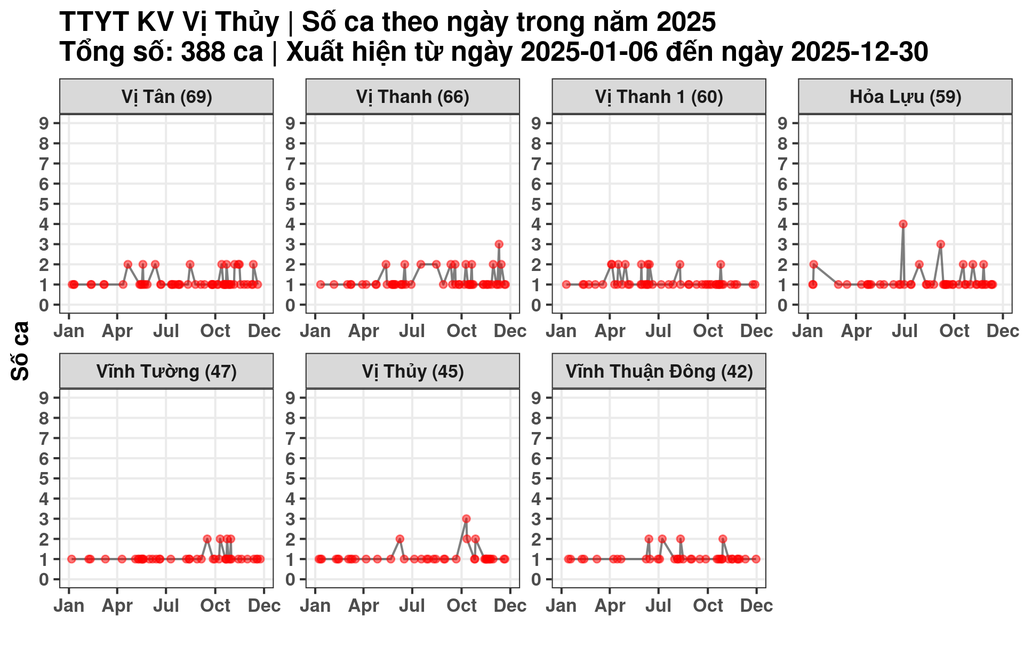

## 8.18 TTYT KV Châu Thành HG

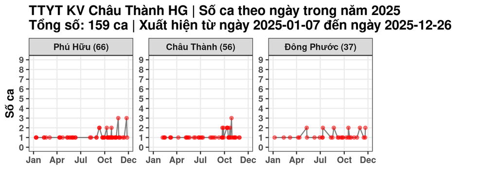

## 8.19 TTYT KV Cái Răng

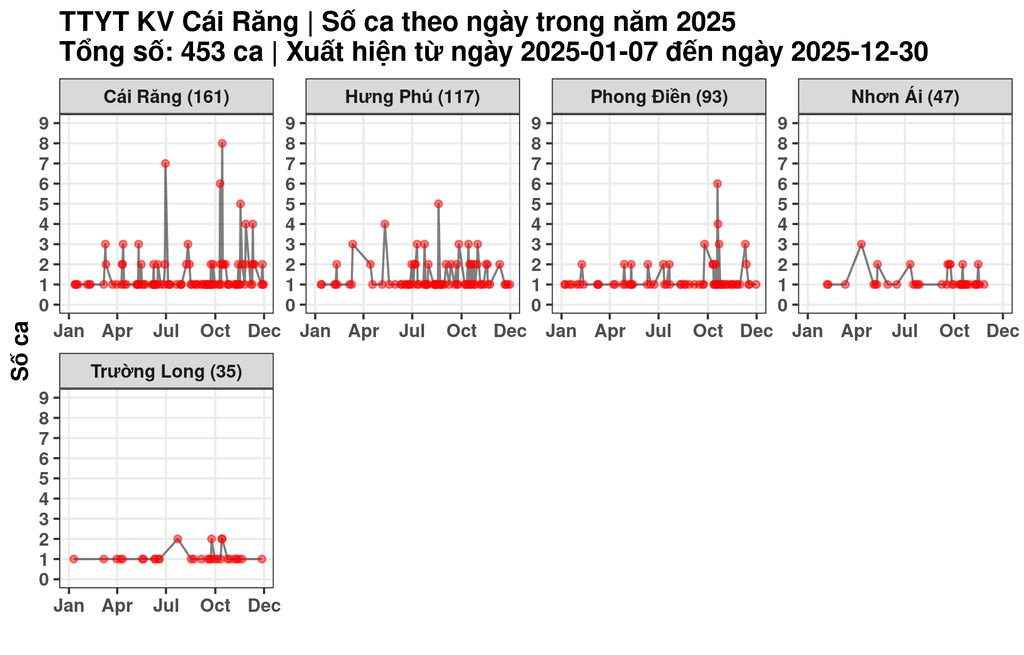

## 8.20 TTYT KV Thạnh Trị

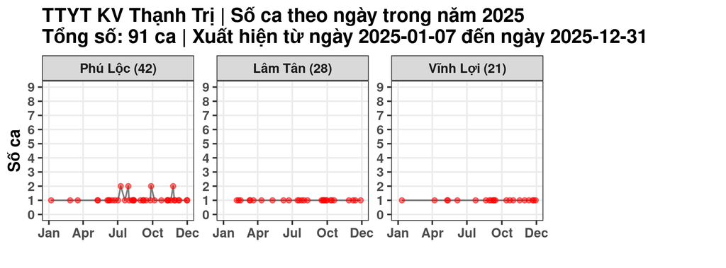

## 8.21 TTYT KV Châu Thành A

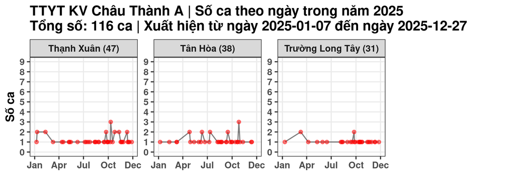

## 8.22 TTYT KV Vĩnh Châu

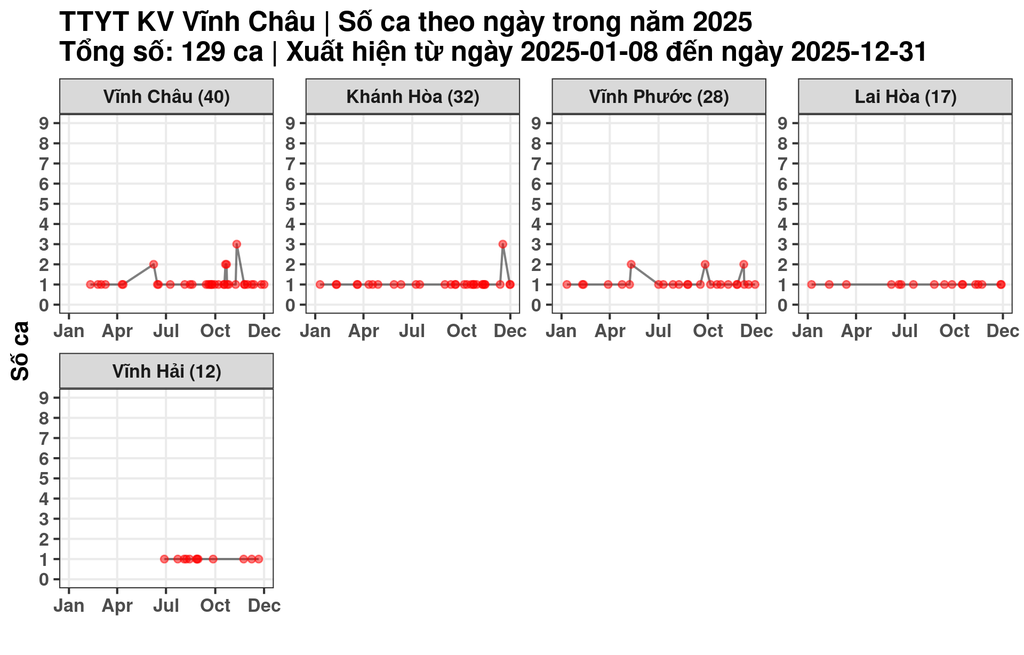

# 9 **ĐỒ THỊ THEO TUẦN**

## 9.1 TTYT KV Bình Thủy

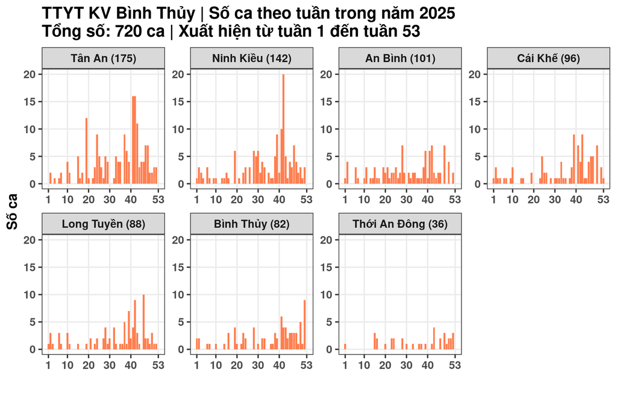

## 9.2 TTYT KV Kế Sách

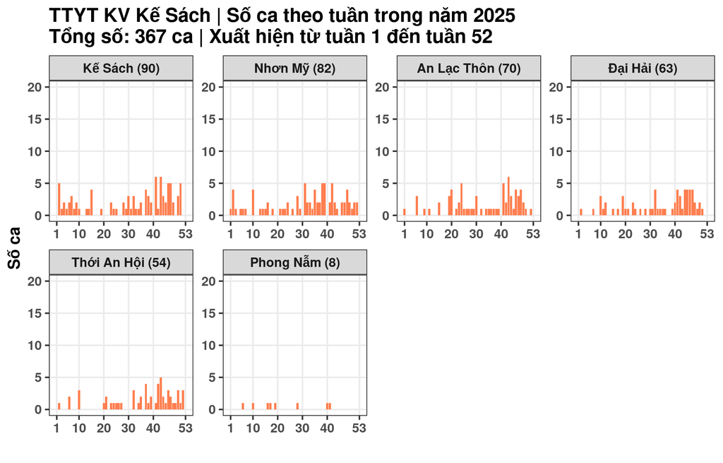

## 9.3 TTYT KV Châu Thành ST

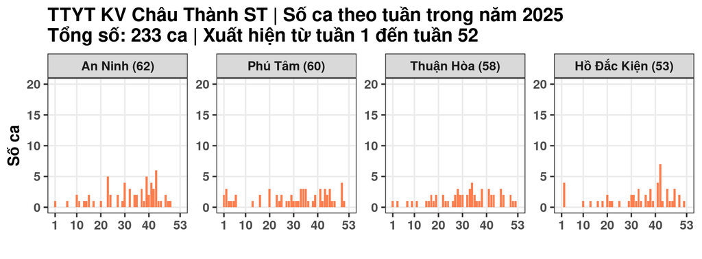

## 9.4 TTYT KV Cù Lao Dung

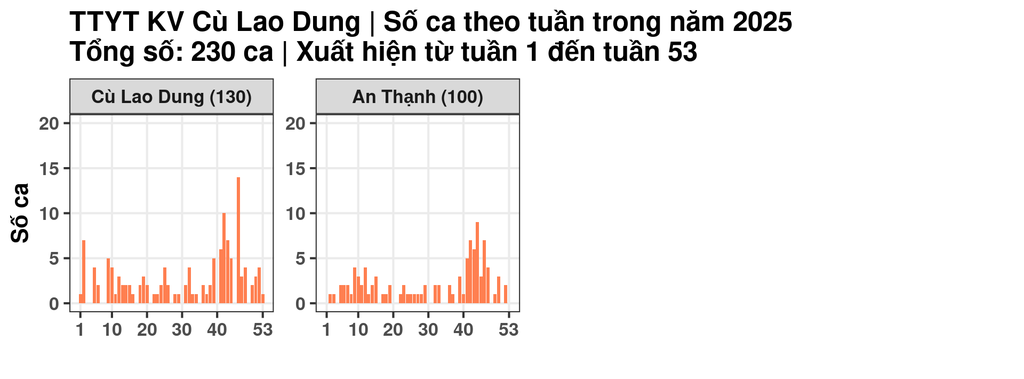

## 9.5 TTYT KV Long Phú

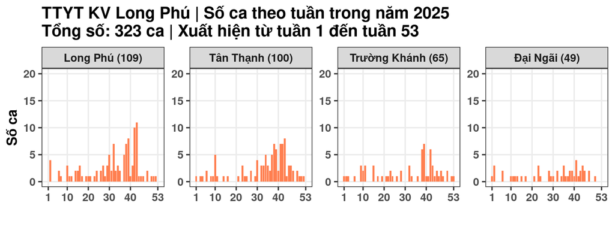

## 9.6 TTYT KV Châu Thành HG

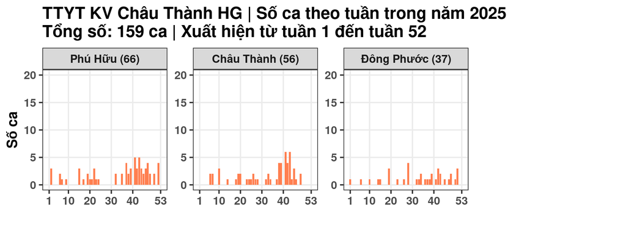

## 9.7 TTYT KV Long Mỹ

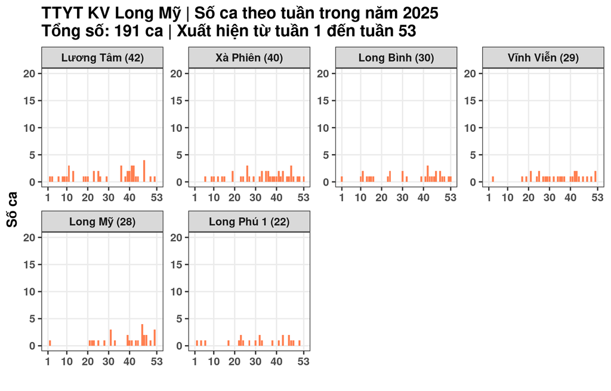